# Workflow Basics

Antes de seguir con el curso, debemos tener una base solida en el lenguaje R.

#### R como calculadora

```r
1 + 10
```

```
## [1] 11
```

```r
1 - 10
```

```
## [1] -9
```

```r
(1 + 9) * (1 - 10)
```

```
## [1] -90
```

```r
10 / 10
```

```
## [1] 1
```

#### Funciones Matematicas

```r
sin(0)
```

```
## [1] 0
```

```r
cos(0)
```

```
## [1] 1
```

```r
log(1)
```

```
## [1] 0
```

```r
exp(1)
```

```
## [1] 2.718282
```

```r
log(exp(1))
```

```
## [1] 1
```

#### Asignacion de valores a objetos

```r
x <- 10
1 + x
```

```
## [1] 11
```

```r
y <- 1 + x
y
```

```
## [1] 11
```

Como buena práctica los nombres debende iniciar con una letra, y contener solo letras, números, _, y .. Nombres descriptivos y una convención para multiples palabras.

Buenas practicas, asignar valores a objetos.

```r
variable_descripcion1 <- 10 * 10
variable.descripcion1 <- 10 * 10
```

Para imprimir los valores solo base escribir el nombre de nuestras variables

```r
variable_descripcion1
```

```
## [1] 100
```

```r
variable.descripcion1
```

```
## [1] 100
```

En caso de no recordar que objetos tenemos creados, funcion util para conocer nuestros objetos.

```r
ls()
```

```
## [1] "variable_descripcion1" "variable.descripcion1" "x"
## [4] "y"
```

#### Funciones de llamada

R tiene una gran coleccion de funciones listas para usar, como analistas de datos es nuestro deber conocer y entender un gran numero de funciones utiles.

Antes de empezar a trabajar con funciones es importante conocer su estructura, el siguiente codigo ejemplifica como se definiria la suma en R

```r
suma <- function(val1,val2) {
  val1 + val2
}
```

Uso de nuestra funcion suma

```r
suma(1,10)
```

```
## [1] 11
```

Definicion de una operacion inventada

```r
operacion <- function(val1, val2){
  (val1/val2)*10
}
```

Uso de nuestra funcion operacion

```r
operacion(10,100)
```

```
## [1] 1
```

No ahi que abrumarnos con esto, no definiremos cada funcion con la trabajaremos. R ya tiene sus propias Funciones que nos facilitaran el trabajo.

```r
sum(1,10)
```

```
## [1] 11
```

Secuencia de numeros

```r
secuencia_1 <- seq(1,10)
secuencia_1
```

```
##  [1]  1  2  3  4  5  6  7  8  9 10
```

Las funciones tambien contienen parametros, los cuales enriquecen su uso. En este caso el parametreo length.out = 5, solo colocara 5 elementos del 1 al 10 con las misma longitud.

```r
secuencia_2 <- seq(1,10, length.out = 5)
secuencia_2
```

```
## [1]  1.00  3.25  5.50  7.75 10.00
```

Otro truco para escribir codigo es;

```r
(secuencia_2 <- seq(1,10, length.out = 5))
```

```
## [1]  1.00  3.25  5.50  7.75 10.00
```

# Practica

¿Por que este codigo no funciona?

```r
my_variable <- 10
#my_varıable
```

Por el símbolo que se encuentra en lugar de una i, si lo cambiamos el codigo funcionará.

```r
my_variable <- 10
my_variable
```

```
## [1] 10
```

Código arreglado

```r
library(tidyverse)
```

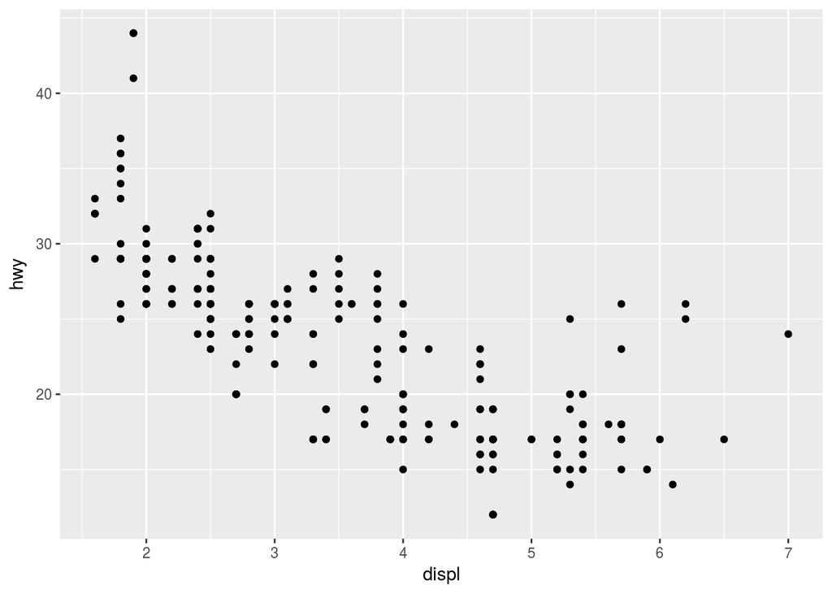

```r
ggplot(data = mpg) +
geom_point(mapping = aes(x = displ, y = hwy))
```

```r
filter(mpg, cyl == 8)
```

```
## # A tibble: 70 x 11
##    manufacturer model     displ  year   cyl trans  drv     cty   hwy fl
##    <chr>        <chr>     <dbl> <int> <int> <chr>  <chr> <int> <int> <chr>
##  1 audi         a6 quatt…   4.2  2008     8 auto(… 4        16    23 p
##  2 chevrolet    c1500 su…   5.3  2008     8 auto(… r        14    20 r
##  3 chevrolet    c1500 su…   5.3  2008     8 auto(… r        11    15 e
##  4 chevrolet    c1500 su…   5.3  2008     8 auto(… r        14    20 r
##  5 chevrolet    c1500 su…   5.7  1999     8 auto(… r        13    17 r
##  6 chevrolet    c1500 su…   6    2008     8 auto(… r        12    17 r
##  7 chevrolet    corvette    5.7  1999     8 manua… r        16    26 p
##  8 chevrolet    corvette    5.7  1999     8 auto(… r        15    23 p
##  9 chevrolet    corvette    6.2  2008     8 manua… r        16    26 p
## 10 chevrolet    corvette    6.2  2008     8 auto(… r        15    25 p
## # ... with 60 more rows, and 1 more variable: class <chr>
```

```r
filter(diamonds, carat > 3)
```

```
## # A tibble: 32 x 10
##    carat cut     color clarity depth table price     x     y     z
##    <dbl> <ord>   <ord> <ord>   <dbl> <dbl> <int> <dbl> <dbl> <dbl>
##  1  3.01 Premium I     I1       62.7    58  8040  9.1   8.97  5.67
##  2  3.11 Fair    J     I1       65.9    57  9823  9.15  9.02  5.98
##  3  3.01 Premium F     I1       62.2    56  9925  9.24  9.13  5.73
##  4  3.05 Premium E     I1       60.9    58 10453  9.26  9.25  5.66
##  5  3.02 Fair    I     I1       65.2    56 10577  9.11  9.02  5.91
##  6  3.01 Fair    H     I1       56.1    62 10761  9.54  9.38  5.31
##  7  3.65 Fair    H     I1       67.1    53 11668  9.53  9.48  6.38
##  8  3.24 Premium H     I1       62.1    58 12300  9.44  9.4   5.85
##  9  3.22 Ideal   I     I1       62.6    55 12545  9.49  9.42  5.92
## 10  3.5  Ideal   H     I1       62.8    57 12587  9.65  9.59  6.03
## # ... with 22 more rows
```